# Thema 5 · Correlatie

Deel 3 — Samenhang · *bewegen ze samen?*

# Twee variabelen tegelijk

Tot nu toe keken we naar één variabele per keer. Nu twee. De egels worden ouder én langer — en de vraag is: **bewegen die twee samen?** Niet door de tijd, maar in de data: horen hogere leeftijden bij hogere (of juist lagere) lengtes? Als een egel ouder is, is hij dan ook langer? Dat is **samenhang** (correlatie, verband, associatie — allemaal hetzelfde, zie Deel 0).

**OpmerkingDe egels — nu met leeftijd erbij**

Bij elke egel meten we nu twee dingen: leeftijd $x$ (maanden) en lengte $y$ (cm).

| $i$ | leeftijd $x_i$ | lengte $y_i$ |
| --- | --- | --- |
| 1 | 2 | 11 |
| 2 | 2 | 20 |
| 3 | 3 | 14 |
| 4 | 3 | 23 |
| 5 | 4 | 20 |
| 6 | 5 | 26 |
| 7 | 5 | 29 |
| 8 | 6 | 17 |
| 9 | 6 | 20 |

De lengtes zijn dezelfde negen als in Deel 1: $\bar{y} = 20$, $s_y = \sqrt{31{,}5} \approx 5{,}61$. Voor de leeftijd: $\bar{x} = 4$, en (reken na) $s_x = \sqrt{2{,}5} \approx 1{,}58$.

Hier is de **wolk** — negen egels, elk een puntje:

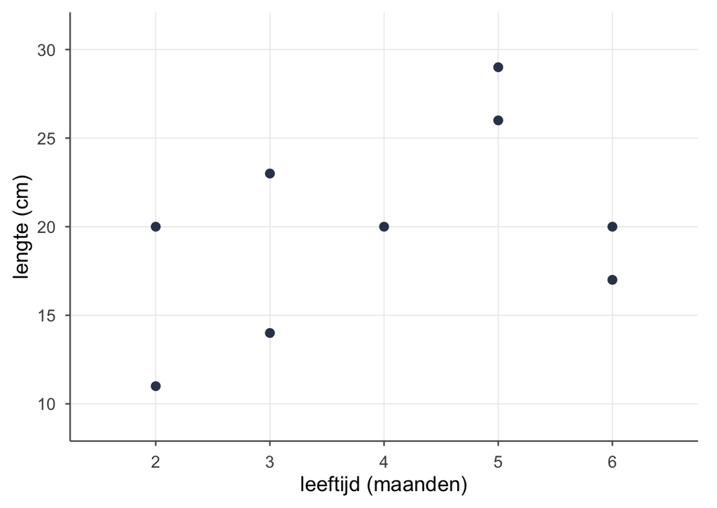

Figuur 1: Spreidingsdiagram van de negen egels: leeftijd (maanden) op de horizontale as, lengte (cm) op de verticale as. Elke egel is één punt. Globaal lopen oudere egels iets hoger (langer), maar er zit duidelijk ruis op de wolk.

Kijk er even naar vóór je verder leest: zie je een verband? En valt je iets op — zit er een egel tussen die juist *tegen* de trend in lijkt te gaan?

# Het gevoel: vier kwadranten

Teken een verticale lijn op $\bar{x} = 4$ en een horizontale op $\bar{y} = 20$. Dat hakt de wolk in vier kwadranten. Loop nu elke egel langs en vraag twee dingen: scoort hij **hoog of laag op leeftijd**, en **hoog of laag op lengte**?

- **Zelfde kant op** (hoog-hoog óf laag-laag) → draagt bij aan een **positief** verband.
- **Tegengesteld** (hoog-laag óf laag-hoog) → draagt bij aan een **negatief** verband.
- **Precies op een gemiddelde** (geen beweging op leeftijd óf op lengte) → draagt **niks** bij.

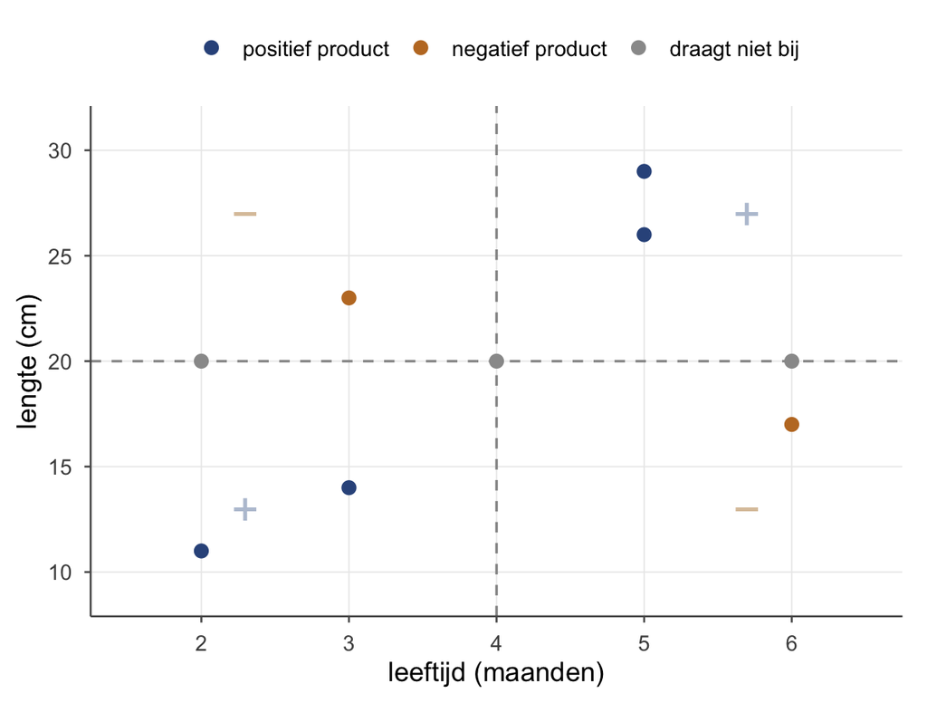

Figuur 2: Dezelfde egels, nu met de gemiddelde-lijnen (stippellijnen op leeftijd 4 en lengte 20) die de wolk in vier kwadranten delen. Blauw = positief product (gaat mee met het verband), oranje = negatief product (dwarsligger), grijs = ligt op een gemiddelde en draagt niets bij. Het teken in elke hoek is het teken van het product van de twee afwijkingen.

# Covariantie: samen afwijken

We vangen dat in een getal. Per egel vermenigvuldigen we zijn afwijking op $x$ met zijn afwijking op $y$ — een **kruisproduct**. Min × min = plus, dus *laat je niet vangen door min-min: dat is gewoon plus.* Aan het teken van het product zie je of een egel aan een positief of negatief verband bijdraagt — en een product van nul betekent: doet niet mee.

| $i$ | $x_i$ | $y_i$ | $x_i-\bar{x}$ | $y_i-\bar{y}$ | product |
| --- | --- | --- | --- | --- | --- |
| 1 | 2 | 11 | −2 | −9 | 18 |
| 2 | 2 | 20 | −2 | 0 | 0 |
| 3 | 3 | 14 | −1 | −6 | 6 |
| 4 | 3 | 23 | −1 | +3 | −3 |
| 5 | 4 | 20 | 0 | 0 | 0 |
| 6 | 5 | 26 | +1 | +6 | 6 |
| 7 | 5 | 29 | +1 | +9 | 9 |
| 8 | 6 | 17 | +2 | −3 | −6 |
| 9 | 6 | 20 | +2 | 0 | 0 |
|  |  |  |  | **som** | **30** |

De som van de producten is 30. Deel door $n-1$ (net als bij de variantie in Deel 1 — we beschrijven een *steekproef*) en je hebt de **covariantie**:

$$s_{xy} = \frac{\sum (x_i-\bar{x})(y_i-\bar{y})}{n-1} = \frac{30}{8} = 3{,}75$$

Merk op: de twee dwarsliggers (egels 4 en 8, met een negatief product) drukken de som omlaag. Zonder hen zou het verband sterker ogen — maar zo eerlijk is de natuur niet.

# Ruw is ruk → de Pearson-correlatie

Die covariantie van 3,75 — is dat veel? **Ruw is ruk.** Hij hangt af van de eenheden (maanden, centimeters), dus je kunt ’m niet interpreteren; alleen het téken (positief) zegt iets. We standaardiseren naar de **Pearson-correlatie** $r_{xy}$, die altijd netjes tussen −1 en +1 loopt. De truc: we delen de **gezamenlijke** beweging (de covariantie) door hoeveel $x$ en $y$ ieder **los** spreiden ($s_x$ en $s_y$):

$$r_{xy} = \frac{s_{xy}}{s_x \cdot s_y} = \frac{3{,}75}{\sqrt{2{,}5}\cdot\sqrt{31{,}5}} = \frac{3{,}75}{8{,}87} \approx 0{,}42$$

**TipVerklaarde variantie: r²**

Kwadrateer je $r$, dan krijg je het aandeel **gedeelde variatie**: $r_{xy}^2 = 0{,}42^2 \approx 0{,}18$. Oftewel: zo’n 18% van de variatie in lengte hangt samen met de variatie in leeftijd (en dat mag je omdraaien). De overige 82% hangt (nog) niet samen met leeftijd — er speelt veel meer mee dan leeftijd alleen.

# Pas op

- **Lineariteit.** $r$ meet alleen *rechte* samenhang. Je kunt door elke wolk een rechte lijn leggen, maar is dat terecht? Een kromme “hema-worst” verstop je niet in een $r$ — teken altijd eerst de scatterplot.
- **Uitbijters** kunnen $r$ flink optillen of platdrukken; één extreem punt doet veel.
- **Schaal maakt niet uit.** Meet je lengte in cm of in meters, $r$ blijft gelijk — hij is gestandaardiseerd.
- **Correlatie ≠ causatie.** De egels worden langer *met* de leeftijd, niet noodzakelijk *vanwege* de leeftijd — ze groeien door voedsel, zorg en een beetje liefde. Tijd is geen oorzaak; het is een meeloper. Pas dus op met het woord “invloed”: dat is iets causaals, en daar gaat een correlatie niet over.

**TipGevoel ontwikkelen**

Wil je leren hoe een wolk en een $r$ bij elkaar horen: speel een paar potjes *guess the correlation* (online te vinden). Een strakke, smalle wolk is makkelijk te raden; een ronde wolk ($r \approx 0$) is lastig. Goede oefening vóór je gaat rekenen.

# Oefenen

**OpmerkingT5.1 — Wie draagt bij, wie werkt tegen?**

Kijk naar de productentabel hierboven.

1. Welke egel draagt het meest bij aan het positieve verband?
2. Twee egels hebben een **negatief** product — welke, en wat is er bijzonder aan die egels?
3. Drie egels dragen niks bij — waarom niet?
4. Wat zou er met $r$ gebeuren als álle egels precies even oud (leeftijd 4) waren?

**OpgeletAntwoord T5.1**

**(a)** Egel 1 (leeftijd 2, lengte 11): de jongste én de kortste, dus van beide gemiddelden ver de “goede” kant op → product 18.

**(b)** Egel 4 (leeftijd 3, lengte 23) en egel 8 (leeftijd 6, lengte 17). Het zijn **dwarsliggers**: egel 4 is jong maar tóch al lang, egel 8 is oud maar kort gebleven. Ze gaan tegen de trend in, dus hun product is negatief (−3 en −6) en ze drukken de covariantie omlaag.

**(c)** Egels 2, 5 en 9 liggen precies op de lengte-gemiddelde lijn (lengte 20): hun afwijking op $y$ is 0, dus het product is 0 — wat hun leeftijd ook is. Ze scoren gemiddeld op lengte en zeggen daarom niets over de samenhang.

**(d)** Dan is er geen variatie in leeftijd ($x_i - \bar{x} = 0$ voor iedereen), dus alle producten zijn 0, de covariantie is 0 en $r = 0$. Zonder verschil in $x$ kan er geen samenhang zijn — je hebt verschil nodig.

**OpmerkingT5.2 — Interpreteren**

Een onderzoeker vindt tussen schoenmaat en leesvaardigheid bij kinderen een correlatie van $r = 0{,}70$. Mogen we concluderen dat grotere voeten beter lezen veroorzaken? Wat is hier waarschijnlijk aan de hand?

**OpgeletAntwoord T5.2**

Nee — correlatie ≠ causatie. Er is vermoedelijk een **derde variabele** die met beide samenhangt: **leeftijd**. Oudere kinderen hebben grotere voeten én lezen beter. De schoenmaat doet niks; leeftijd loopt mee. (Zo’n meeloper heet ook wel een confounder.)

# Tot slot

Correlatie vangt of twee variabelen samen bewegen — het gevoel zit in de vier kwadranten, het getal in de covariantie, en de interpreteerbare maat is de gestandaardiseerde $r$. Maar een verband is een **dubbele pijl**: het zegt niks over richting of voorspelling. In het volgende thema zetten we er een **enkele pijl** op — dan voorspellen we lengte uit leeftijd. Dat is regressie.

*Werkboek OZP 1 · Thema 5, versie 0.1 (handrekenen & theorie; SPSS later). Doorlopend voorbeeld: de egels.*

Terug naar boven